# Spring temperature drives phenotypic selection on plasticity of flowering time

Alicia Valdés

# Read data and check ns

```r
datadef<-read.csv("data/datadef.csv")
head(datadef)
```

|  | year | id_nr | id | fcode | FFD | n_fl | n_fr | totseed | intactseed | shoot_vol | period | n_years_fl_fitness | n_years_study | mean_4 | cmean_4 |
| --- | --- | --- | --- | --- | --- | --- | --- | --- | --- | --- | --- | --- | --- | --- | --- |
| 1 | 1989 | 1 | old_1 | 1 | NA | 6 | 3 | 8 | 6 | 1418.6000 | old | 5 | 8 | 5.236667 | -0.228207783 |
| 2 | 1990 | 1 | old_1 | 0 | NA | 0 | 0 | 0 | 0 | 523.2000 | old | 5 | 8 | 7.195000 | 1.730125551 |
| 3 | 1991 | 1 | old_1 | 1 | 59.91181 | 23 | 3 | 12 | 12 | 1915.4000 | old | 5 | 8 | 5.245000 | -0.219874449 |
| 4 | 1992 | 1 | old_1 | 1 | 55.66944 | 19 | 2 | 6 | 1 | 1460.1917 | old | 5 | 8 | 3.828333 | -1.636541116 |
| 5 | 1993 | 1 | old_1 | 1 | NA | NA | 0 | 0 | 0 | 879.6493 | old | 5 | 8 | 5.461667 | -0.003207783 |
| 6 | 1994 | 1 | old_1 | 1 | 59.18403 | 14 | 1 | 3 | 3 | 1338.6727 | old | 5 | 8 | 6.418333 | 0.953458884 |

Number of individuals in each period:

```r
length(with(subset(datadef,period=="old"),unique(id)))
```

```
[1] 607
```

```r
length(with(subset(datadef,period=="new"),unique(id)))
```

```
[1] 230
```

Number of observations in each period:

```r
nrow(subset(datadef,period=="old"))
```

```
[1] 4606
```

```r
nrow(subset(datadef,period=="new"))
```

```
[1] 2231
```

Number of cases with FFD in each period:

```r
nrow(subset(datadef,period=="old"&!is.na(FFD)))
```

```
[1] 1467
```

```r
nrow(subset(datadef,period=="new"&!is.na(FFD)))
```

```
[1] 1011
```

# Data preparation

```r
datadef_total<-datadef %>%
  group_by(id)%>%
  # Calculate mean fitness per year of study
  # and mean fitness per flowering event
  summarise(mean_fitness_study=sum(intactseed,na.rm=T)/mean(n_years_study),
            mean_fitness_fl=sum(intactseed,na.rm=T)/mean(n_years_fl_fitness))%>%
   arrange(.,id) # Order by id

with(datadef_total,cor(mean_fitness_study,mean_fitness_fl))  # Highly corr (0.87)
```

```
[1] 0.8660685
```

```r
# Calculate mean shoot volume for each id using values of shoot volume
# for all ids/years (including flowering and non-flowering years)

shoot_vol_all_means<-datadef[c(1,3,10)]%>%
  group_by(id)%>%
  summarise(shoot_vol_mean=mean(shoot_vol,na.rm=T))
# Mean of all available values

# Join shoot volume data
datadef_total<-datadef_total%>%left_join(shoot_vol_all_means)%>%
  left_join(unique(datadef[c(2,3,11)]))
head(datadef_total)
```

| id | mean_fitness_study | mean_fitness_fl | shoot_vol_mean | id_nr | period |
| --- | --- | --- | --- | --- | --- |
| new_1 | 0.000000 | 0.000000 | 1830.440 | 1 | new |
| new_10 | 14.348637 | 15.653059 | 9793.766 | 10 | new |
| new_100 | 3.886053 | 5.829080 | 1958.587 | 100 | new |
| new_101 | 2.248523 | 2.998030 | 1195.272 | 101 | new |
| new_102 | 5.607576 | 6.729092 | 3269.373 | 102 | new |
| new_103 | 3.595948 | 4.315138 | 1694.117 | 103 | new |

```r
nrow(subset(datadef_total,is.na(shoot_vol_mean)))
```

```
[1] 46
```

```r
# 46 ids with no info on shoot volume

# Using sqrt of mean shoot volume over all years when available, centred
datadef_total<-datadef_total%>%
  mutate(shoot_vol_mean_sqrt=sqrt(shoot_vol_mean),
         cn_shoot_vol_mean_sqrt=as.vector(scale(shoot_vol_mean_sqrt,center=T,scale=F)))
```

Filter data to keep individuals that flowered in at least 3 years.

```r
datadef3<-datadef%>%filter(n_years_fl_fitness>2)
nrow(filter(datadef3,!is.na(FFD)))
```

```
[1] 1977
```

```r
length(unique((datadef%>%filter(n_years_fl_fitness>2))$id))
```

```
[1] 424
```

1977 flowering events and 424 individuals.

# Hypothesis 1: Univariate models

## Models in Table 1

### Table 1A

FFD with random effect of year only. This model assumes no among-individual variation around the average population-level reaction norm.

```r
my.cores <- detectCores()
```

FFD with random effect of year only. This model assumes no among-individual variation around the average population-level reaction norm.

```r
summary(univar.FFD_yearonly.all.brm3)
```

```
 Family: gaussian
  Links: mu = identity; sigma = identity
Formula: FFD ~ cmean_4 + (1 | year)
   Data: datadef3 (Number of observations: 1977)
  Draws: 4 chains, each with iter = 4000; warmup = 1000; thin = 2;
         total post-warmup draws = 6000

Group-Level Effects:
~year (Number of levels: 22)
              Estimate Est.Error l-95% CI u-95% CI Rhat Bulk_ESS Tail_ESS
sd(Intercept)     5.33      0.91     3.92     7.44 1.00     1496     2494

Population-Level Effects:
          Estimate Est.Error l-95% CI u-95% CI Rhat Bulk_ESS Tail_ESS
Intercept    58.46      1.16    56.17    60.78 1.00     1464     2247
cmean_4      -2.43      0.84    -4.10    -0.79 1.00     1684     2478

Family Specific Parameters:
      Estimate Est.Error l-95% CI u-95% CI Rhat Bulk_ESS Tail_ESS
sigma     4.82      0.08     4.68     4.98 1.00     3987     4630

Draws were sampled using sampling(NUTS). For each parameter, Bulk_ESS
and Tail_ESS are effective sample size measures, and Rhat is the potential
scale reduction factor on split chains (at convergence, Rhat = 1).
```

### Table 1B

FFD with random effects of year and individual-intercept. This model assumes among-individual variation in reaction norm elevation.

```r
summary(univar.FFD.all.brm3)
```

```
 Family: gaussian
  Links: mu = identity; sigma = identity
Formula: FFD ~ cmean_4 + (1 | year) + (1 | id)
   Data: datadef3 (Number of observations: 1977)
  Draws: 4 chains, each with iter = 4000; warmup = 1000; thin = 2;
         total post-warmup draws = 6000

Group-Level Effects:
~id (Number of levels: 424)
              Estimate Est.Error l-95% CI u-95% CI Rhat Bulk_ESS Tail_ESS
sd(Intercept)     1.67      0.15     1.37     1.98 1.00     3932     5124

~year (Number of levels: 22)
              Estimate Est.Error l-95% CI u-95% CI Rhat Bulk_ESS Tail_ESS
sd(Intercept)     5.36      0.92     3.92     7.53 1.00     3112     4071

Population-Level Effects:
          Estimate Est.Error l-95% CI u-95% CI Rhat Bulk_ESS Tail_ESS
Intercept    58.59      1.13    56.33    60.82 1.00     2316     3546
cmean_4      -2.42      0.87    -4.19    -0.66 1.00     2487     3686

Family Specific Parameters:
      Estimate Est.Error l-95% CI u-95% CI Rhat Bulk_ESS Tail_ESS
sigma     4.52      0.08     4.37     4.69 1.00     4527     4755

Draws were sampled using sampling(NUTS). For each parameter, Bulk_ESS
and Tail_ESS are effective sample size measures, and Rhat is the potential
scale reduction factor on split chains (at convergence, Rhat = 1).
```

### Table 1C

Random regression for FFD, including random effects of individual slopes and covariance between intercept and slope. This model assumes among-individual variation in reaction norm elevation and slope.

```r
summary(univar.FFD_RR.all.brm3)
```

```
 Family: gaussian
  Links: mu = identity; sigma = identity
Formula: FFD ~ cmean_4 + (1 | year) + (cmean_4 | id)
   Data: datadef3 (Number of observations: 1977)
  Draws: 4 chains, each with iter = 4000; warmup = 1000; thin = 2;
         total post-warmup draws = 6000

Group-Level Effects:
~id (Number of levels: 424)
                       Estimate Est.Error l-95% CI u-95% CI Rhat Bulk_ESS Tail_ESS
sd(Intercept)              1.59      0.16     1.29     1.90 1.00     3759     4748
sd(cmean_4)                0.76      0.14     0.50     1.02 1.00     3293     4329
cor(Intercept,cmean_4)     0.80      0.14     0.49     0.99 1.00     2398     4073

~year (Number of levels: 22)
              Estimate Est.Error l-95% CI u-95% CI Rhat Bulk_ESS Tail_ESS
sd(Intercept)     5.34      0.89     3.90     7.35 1.00     2975     4435

Population-Level Effects:
          Estimate Est.Error l-95% CI u-95% CI Rhat Bulk_ESS Tail_ESS
Intercept    58.63      1.16    56.30    60.92 1.00     2119     3466
cmean_4      -2.41      0.85    -4.13    -0.74 1.00     2651     3633

Family Specific Parameters:
      Estimate Est.Error l-95% CI u-95% CI Rhat Bulk_ESS Tail_ESS
sigma     4.43      0.08     4.26     4.59 1.00     3712     4384

Draws were sampled using sampling(NUTS). For each parameter, Bulk_ESS
and Tail_ESS are effective sample size measures, and Rhat is the potential
scale reduction factor on split chains (at convergence, Rhat = 1).
```

#### Compare models

This allows us to test if adding among-individual variation in elevation and slope of the RN improves model fit.

```r
loo_comp3<-loo_compare(univar.FFD_yearonly.all.brm3,univar.FFD.all.brm3,
                      univar.FFD_RR.all.brm3, criterion="loo")
```

```r
loo_comp3
```

```
                             elpd_diff se_diff
univar.FFD_RR.all.brm3         0.0       0.0
univar.FFD.all.brm3          -10.4       7.5
univar.FFD_yearonly.all.brm3 -55.4      12.8
```

The results indicate that adding a random intercept (i.e. among-individual variation in RN elevation) improves the fit, and that adding a random slope (i.e. among-individual variation in RN slope) improves the fit even more. Thus, the random regression model is the best model.

#### Bayes_R2

Measure of fit: Bayesian R2, which looks at the model expected variance / (expected variance + residual variance).

```r
bayes_R2(univar.FFD_yearonly.all.brm3)
```

```
    Estimate Est.Error     Q2.5     Q97.5
R2 0.5351344 0.0105961 0.513408 0.5550764
```

```r
bayes_R2(univar.FFD.all.brm3)
```

```
    Estimate  Est.Error      Q2.5     Q97.5
R2 0.5916071 0.01110623 0.5696509 0.6127449
```

```r
bayes_R2(univar.FFD_RR.all.brm3)
```

```
    Estimate Est.Error     Q2.5     Q97.5
R2 0.6086789 0.0114171 0.585319 0.6300294
```

#### Extract BLUPs from random regression model

```r
BLUPs_MCMC.all.brms3  <- cbind(as.factor(c(1:424)),
                              as.data.frame(ranef(univar.FFD_RR.all.brm3)$id)
                              [c(1:2,5:6)])
colnames(BLUPs_MCMC.all.brms3) <- c("id", "intercept", "intercept_sd",
                                   "slope","slope_sd")
with(BLUPs_MCMC.all.brms3,cor(intercept,slope)) # highly correlated!
```

```
[1] 0.9648381
```

Add BLUPs to data set

```r
datadef3<-datadef3%>%left_join(BLUPs_MCMC.all.brms3%>%
                               dplyr::select(intercept,intercept_sd,
                                             slope,slope_sd)%>%
                               rownames_to_column(var="id"))
```

Save data with BLUPs

```r
datadef_total3<-datadef3 %>%
  group_by(id)%>%
  # Calculate mean fitness per year of study
  # and mean fitness per flowering event
  summarise(mean_fitness_study=sum(intactseed,na.rm=T)/mean(n_years_study),
            mean_fitness_fl=sum(intactseed,na.rm=T)/mean(n_years_fl_fitness))%>%
   arrange(.,id) # Order by id

with(datadef_total3,cor(mean_fitness_study,mean_fitness_fl))  # Highly corr (0.91)
```

```
[1] 0.9092765
```

```r
# Join shoot volume data
datadef_total3<-datadef_total3%>%left_join(shoot_vol_all_means)%>%
  left_join(unique(datadef3[c(2,3,11)]))
head(datadef_total3)
```

| id | mean_fitness_study | mean_fitness_fl | shoot_vol_mean | id_nr | period |
| --- | --- | --- | --- | --- | --- |
| new_10 | 14.348637 | 15.653059 | 9793.766 | 10 | new |
| new_100 | 3.886053 | 5.829080 | 1958.587 | 100 | new |
| new_101 | 2.248523 | 2.998030 | 1195.272 | 101 | new |
| new_102 | 5.607576 | 6.729092 | 3269.373 | 102 | new |
| new_103 | 3.595948 | 4.315138 | 1694.117 | 103 | new |
| new_104 | 1.583333 | 2.714286 | 1055.798 | 104 | new |

```r
nrow(subset(datadef_total3,is.na(shoot_vol_mean)))
```

```
[1] 0
```

```r
# 0 ids with no info on shoot volume

# Using sqrt of mean shoot volume over all years when available, centred
datadef_total3<-datadef_total3%>%
  mutate(shoot_vol_mean_sqrt=sqrt(shoot_vol_mean),
         cn_shoot_vol_mean_sqrt=as.vector(scale(shoot_vol_mean_sqrt,center=T,
                                                scale=F)))

datadef3<-left_join(datadef3,datadef_total3[c(1:3,8)])
```

```r
datadef3<-datadef3%>%left_join(datadef_total3%>%
                                 dplyr::select(id,cn_shoot_vol_mean_sqrt))
write_csv(datadef3,file = "data/datadef3_BLUPs.csv")
```

## Hypothesis 2: Bivariate models

## Models in Table 2

### Table 2A NB

Mean fitness per flowering event, with shoot volume.

Using the ID-syntax to specify fitness to be correlated with the intercept and slope of FFD on temperature.

Negative binomial distribution for fitness.

```r
bf_FFD <- bf(FFD ~ cmean_4 + (cmean_4|ID1|id) + (1|year)) # Set up model formula
bf_fitness_shoot <- bf(round(mean_fitness_fl) ~  cn_shoot_vol_mean_sqrt +
                         (1|ID1|id)) # Set up model formula
# Specifying group-level effects of the same grouping factor (id here)
# to be correlated across formulas
# Expand the | operator into |<ID>|, where <ID> can be any value (ID1 here)
# Group-level terms with the same ID1 will be modeled as correlated
# if they share same grouping factor(s)
```

```r
bivar2.all.brm.nb3<-brm(bf_FFD+bf_fitness_shoot,
                       family = c(gaussian,negbinomial),
                       data = datadef3,warmup = 1000,iter = 6000,chains=4,thin=2,
                       inits = "random",seed = 12345,cores = my.cores,
                       control = list(adapt_delta = 0.99))
```

```r
print(bivar2.all.brm.nb3,digits=3)
```

```
 Family: MV(gaussian, negbinomial)
  Links: mu = identity; sigma = identity
         mu = log; shape = identity
Formula: FFD ~ cmean_4 + (cmean_4 | ID1 | id) + (1 | year)
         round(mean_fitness_fl) ~ cn_shoot_vol_mean_sqrt + (1 | ID1 | id)
   Data: datadef3 (Number of observations: 1977)
  Draws: 4 chains, each with iter = 6000; warmup = 1000; thin = 2;
         total post-warmup draws = 10000

Group-Level Effects:
~id (Number of levels: 424)
                                                Estimate Est.Error l-95% CI u-95% CI  Rhat Bulk_ESS
sd(FFD_Intercept)                                  1.601     0.161    1.284    1.920 1.000     5701
sd(FFD_cmean_4)                                    0.764     0.141    0.492    1.043 1.001     2480
sd(roundmeanfitnessfl_Intercept)                   0.931     0.044    0.850    1.020 1.001     5101
cor(FFD_Intercept,FFD_cmean_4)                     0.757     0.139    0.444    0.964 1.004      759
cor(FFD_Intercept,roundmeanfitnessfl_Intercept)   -0.322     0.092   -0.495   -0.137 1.002     1153
cor(FFD_cmean_4,roundmeanfitnessfl_Intercept)      0.025     0.141   -0.246    0.299 1.005      455
                                                Tail_ESS
sd(FFD_Intercept)                                   7634
sd(FFD_cmean_4)                                     6522
sd(roundmeanfitnessfl_Intercept)                    7569
cor(FFD_Intercept,FFD_cmean_4)                      3160
cor(FFD_Intercept,roundmeanfitnessfl_Intercept)     3331
cor(FFD_cmean_4,roundmeanfitnessfl_Intercept)       1029

~year (Number of levels: 22)
                  Estimate Est.Error l-95% CI u-95% CI  Rhat Bulk_ESS Tail_ESS
sd(FFD_Intercept)    5.339     0.891    3.918    7.405 1.001     4362     7436

Population-Level Effects:
                                          Estimate Est.Error l-95% CI u-95% CI  Rhat Bulk_ESS
FFD_Intercept                               58.579     1.155   56.295   60.869 1.001     2944
roundmeanfitnessfl_Intercept                 1.131     0.049    1.035    1.225 1.000     7299
FFD_cmean_4                                 -2.381     0.852   -4.055   -0.700 1.000     3612
roundmeanfitnessfl_cn_shoot_vol_mean_sqrt    0.031     0.004    0.023    0.039 1.002     6188
                                          Tail_ESS
FFD_Intercept                                 5296
roundmeanfitnessfl_Intercept                  8713
FFD_cmean_4                                   6205
roundmeanfitnessfl_cn_shoot_vol_mean_sqrt     7221

Family Specific Parameters:
                         Estimate Est.Error l-95% CI u-95% CI  Rhat Bulk_ESS Tail_ESS
sigma_FFD                   4.428     0.081    4.272    4.587 1.001     3680     7470
shape_roundmeanfitnessfl  660.472   186.860  369.334 1084.029 1.000     7529     7739

Draws were sampled using sampling(NUTS). For each parameter, Bulk_ESS
and Tail_ESS are effective sample size measures, and Rhat is the potential
scale reduction factor on split chains (at convergence, Rhat = 1).
```

Measure of fit: Bayesian R2

```r
bayes_R2(bivar2.all.brm.nb3)
```

```
                      Estimate   Est.Error      Q2.5     Q97.5
R2FFD                0.6084066 0.011436353 0.5855015 0.6306460
R2roundmeanfitnessfl 0.9517087 0.004653736 0.9416526 0.9598579
```

#### Extract selection coefficients

```r
sample.gmat2 <- function(data, replicates = 6000) {

  ##Initialize the results list (list of lists)
  foo <- list(gmat = matrix(rep(0,3*3), ncol = 3))
  results.list <- list()
  for(j in 1:replicates) { results.list[[j]] <- foo }

  for(i in 1:replicates) {
    diag(results.list[[i]]$gmat) <- data[i,5:7]^2 #Get the diagonal

    #Upper diagonal
    results.list[[i]]$gmat[1,2] <- data[i,5]*data[i,6]*data[i,9]
    results.list[[i]]$gmat[1,3] <- data[i,5]*data[i,7]*data[i,10]
    results.list[[i]]$gmat[2,3] <- data[i,6]*data[i,7]*data[i,11]

    #Lower diagonal
    results.list[[i]]$gmat[2,1] <- results.list[[i]]$gmat[1,2]
    results.list[[i]]$gmat[3,1] <- results.list[[i]]$gmat[1,3]
    results.list[[i]]$gmat[3,2] <- results.list[[i]]$gmat[2,3]

  }

  return(results.list)
}
```

```r
# Extract posterior samples
bivar2.all.brm.nb3_post <- posterior_samples(bivar2.all.brm.nb3)
bivar2.all.brm.nb3_post <- as.mcmc(bivar2.all.brm.nb3_post)

sampled.gmat9 <- sample.gmat2(bivar2.all.brm.nb3_post, replicates = 6000)

sgmat9 <- lapply(sampled.gmat9, `[`, c('gmat')) #Get list 'gmat' from each list
sgmat9 <- unname(sapply(sgmat9, '[[', 1)) #Change to matrix

sgmat9 <- t(sgmat9)

P.modelBV_RR9 <- sgmat9
P.modelBV_RR9.mode <- matrix(1:9, nrow = 3)
for (k in 1:9) P.modelBV_RR9.mode[k] <- posterior.mode(mcmc(sgmat9[,k]))

# Extract selection *differentials* (i.e. covariances) for intercept and slope:
# and calculate posterior mode and credible intervals for each
S.modelBV_RR9 <- sgmat9[,c(3,6)]
colnames(S.modelBV_RR9) <- c("S_intercepts", "S_slopes")
S.modelBV_RR9.mode <- P.modelBV_RR9.mode[1:2, 3]

posterior.mode(mcmc(S.modelBV_RR9))
```

```
S_intercepts     S_slopes
 -0.47283522  -0.01502566
```

```r
HPDinterval(mcmc(S.modelBV_RR9))
```

```
                  lower      upper
S_intercepts -0.7576679 -0.1866180
S_slopes     -0.1853695  0.2077096
attr(,"Probability")
[1] 0.95
```

```r
# Estimate selection gradients for intercept and slope (beta = S / P)
# on each sample of posterior and extract their mode
beta_post_RR9 <- matrix(NA, nrow(S.modelBV_RR9) ,2)

for (i in 1:nrow(S.modelBV_RR9)) {
  P3_9 <- matrix(rep(NA, 9), nrow = 3)
  # 3x3 matrix of var-cov for individual X.int, X.slope and fitness
  for (k in 1:9) {P3_9[k] <- P.modelBV_RR9[i, k] }
  P2_9 <- P3_9[1:2, 1:2]   # 2x2 matrix of just trait intercept & slope var-cov
  S9 <- P3_9[1:2, 3]   # selection differentials on traits (last column of P3)
  beta_post_RR9[i,] <- solve(P2_9) %*% S9   # selection gradients beta = P^-1 * S
}

colnames(beta_post_RR9) <- c("beta_intercepts", "beta_slopes")
posterior.mode(mcmc(beta_post_RR9))
```

```
beta_intercepts     beta_slopes
     -0.3589045       0.4368692
```

```r
HPDinterval(mcmc(beta_post_RR9))
```

```
                     lower       upper
beta_intercepts -1.5379260 -0.05034681
beta_slopes     -0.1813048  3.50167553
attr(,"Probability")
[1] 0.95
```

### Table 2A ZINB

```r
bivar2.all.brm.nb3_zi<-brm(bf_FFD+bf_fitness_shoot,
                       family = c(gaussian,zero_inflated_negbinomial),
                       data = datadef3,warmup = 1000,iter = 6000,chains=4,thin=2,
                       inits = "random",seed = 12345,cores = my.cores,
                       control = list(adapt_delta = 0.99))
```

#### Extract selection coefficients

```r
# Extract posterior samples
bivar2.all.brm.nb3_zi_post <- posterior_samples(bivar2.all.brm.nb3_zi)
bivar2.all.brm.nb3_zi_post <- as.mcmc(bivar2.all.brm.nb3_zi_post)

sampled.gmat9_zi <- sample.gmat2(bivar2.all.brm.nb3_zi_post, replicates = 6000)

sgmat9_zi <- lapply(sampled.gmat9_zi, `[`, c('gmat')) #Get list 'gmat' from each list
sgmat9_zi <- unname(sapply(sgmat9_zi, '[[', 1)) #Change to matrix

sgmat9_zi <- t(sgmat9_zi)

P.modelBV_RR9_zi <- sgmat9_zi
P.modelBV_RR9_zi.mode <- matrix(1:9, nrow = 3)
for (k in 1:9) P.modelBV_RR9_zi.mode[k] <- posterior.mode(mcmc(sgmat9_zi[,k]))

# Extract selection *differentials* (i.e. covariances) for intercept and slope:
# and calculate posterior mode and credible intervals for each
S.modelBV_RR9_zi <- sgmat9_zi[,c(3,6)]
colnames(S.modelBV_RR9_zi) <- c("S_intercepts", "S_slopes")
S.modelBV_RR9_zi.mode <- P.modelBV_RR9_zi.mode[1:2, 3]

posterior.mode(mcmc(S.modelBV_RR9_zi))
HPDinterval(mcmc(S.modelBV_RR9_zi))

# Estimate selection gradients for intercept and slope (beta = S / P)
# on each sample of posterior and extract their mode
beta_post_RR9_zi <- matrix(NA, nrow(S.modelBV_RR9_zi) ,2)

for (i in 1:nrow(S.modelBV_RR9_zi)) {
  P3_9_zi <- matrix(rep(NA, 9), nrow = 3)
  # 3x3 matrix of var-cov for individual X.int, X.slope and fitness
  for (k in 1:9) {P3_9_zi[k] <- P.modelBV_RR9_zi[i, k] }
  P2_9_zi <- P3_9_zi[1:2, 1:2]   # 2x2 matrix of just trait intercept & slope var-cov
  S9_zi <- P3_9_zi[1:2, 3]   # selection differentials on traits (last column of P3)
  beta_post_RR9_zi[i,] <- solve(P2_9_zi) %*% S9_zi   # selection gradients beta = P^-1 * S
}

colnames(beta_post_RR9_zi) <- c("beta_intercepts", "beta_slopes")
posterior.mode(mcmc(beta_post_RR9_zi))
HPDinterval(mcmc(beta_post_RR9_zi))
```

### Table 2B

Mean fitness per year of study, with shoot volume.

Negative binomial distribution for fitness.

```r
bf_fitness_study_shoot <- bf(round(mean_fitness_study) ~
                               cn_shoot_vol_mean_sqrt +
                         (1|ID1|id)) # Set up model formula
```

```r
bivar4.all.brm.nb3<-brm(bf_FFD+bf_fitness_study_shoot,
                       family = c(gaussian,negbinomial),
                       data = datadef3,warmup = 1000,iter = 6000,chains=4,thin=2,
                       inits = "random",seed = 12345,cores = my.cores)
```

```r
print(bivar4.all.brm.nb3,digits=3)
```

```
 Family: MV(gaussian, negbinomial)
  Links: mu = identity; sigma = identity
         mu = log; shape = identity
Formula: FFD ~ cmean_4 + (cmean_4 | ID1 | id) + (1 | year)
         round(mean_fitness_study) ~ cn_shoot_vol_mean_sqrt + (1 | ID1 | id)
   Data: datadef3 (Number of observations: 1977)
  Draws: 4 chains, each with iter = 6000; warmup = 1000; thin = 2;
         total post-warmup draws = 10000

Group-Level Effects:
~id (Number of levels: 424)
                                                   Estimate Est.Error l-95% CI u-95% CI  Rhat
sd(FFD_Intercept)                                     1.614     0.156    1.312    1.922 1.001
sd(FFD_cmean_4)                                       0.777     0.137    0.512    1.044 1.001
sd(roundmeanfitnessstudy_Intercept)                   0.899     0.045    0.815    0.993 1.001
cor(FFD_Intercept,FFD_cmean_4)                        0.742     0.129    0.444    0.943 1.003
cor(FFD_Intercept,roundmeanfitnessstudy_Intercept)   -0.396     0.088   -0.564   -0.222 1.002
cor(FFD_cmean_4,roundmeanfitnessstudy_Intercept)      0.013     0.139   -0.263    0.288 1.005
                                                   Bulk_ESS Tail_ESS
sd(FFD_Intercept)                                      5733     7642
sd(FFD_cmean_4)                                        4040     7335
sd(roundmeanfitnessstudy_Intercept)                    5287     7104
cor(FFD_Intercept,FFD_cmean_4)                         1193     4535
cor(FFD_Intercept,roundmeanfitnessstudy_Intercept)     1970     4408
cor(FFD_cmean_4,roundmeanfitnessstudy_Intercept)       1061     2130

~year (Number of levels: 22)
                  Estimate Est.Error l-95% CI u-95% CI  Rhat Bulk_ESS Tail_ESS
sd(FFD_Intercept)    5.390     0.901    3.958    7.469 1.000     3946     6549

Population-Level Effects:
                                             Estimate Est.Error l-95% CI u-95% CI  Rhat Bulk_ESS
FFD_Intercept                                  58.637     1.171   56.364   60.959 1.001     2527
roundmeanfitnessstudy_Intercept                 0.558     0.051    0.458    0.656 1.000     8126
FFD_cmean_4                                    -2.455     0.877   -4.180   -0.747 1.001     2961
roundmeanfitnessstudy_cn_shoot_vol_mean_sqrt    0.043     0.004    0.035    0.052 1.000     7181
                                             Tail_ESS
FFD_Intercept                                    4431
roundmeanfitnessstudy_Intercept                  8906
FFD_cmean_4                                      5601
roundmeanfitnessstudy_cn_shoot_vol_mean_sqrt     8243

Family Specific Parameters:
                            Estimate Est.Error l-95% CI u-95% CI  Rhat Bulk_ESS Tail_ESS
sigma_FFD                      4.422     0.081    4.264    4.580 1.001     4894     7460
shape_roundmeanfitnessstudy  554.312   171.957  293.407  955.128 1.000     7899     8220

Draws were sampled using sampling(NUTS). For each parameter, Bulk_ESS
and Tail_ESS are effective sample size measures, and Rhat is the potential
scale reduction factor on split chains (at convergence, Rhat = 1).
```

Measure of fit: Bayesian R2

```r
bayes_R2(bivar4.all.brm.nb3)
```

```
                         Estimate   Est.Error      Q2.5     Q97.5
R2FFD                   0.6096603 0.011209740 0.5870020 0.6314364
R2roundmeanfitnessstudy 0.9513545 0.005091556 0.9404877 0.9601141
```

#### Extract selection coefficients

```r
# Extract posterior samples
bivar4.all.brm.nb3_post <- posterior_samples(bivar4.all.brm.nb3)
bivar4.all.brm.nb3_post <- as.mcmc(bivar4.all.brm.nb3_post)

sampled.gmat10 <- sample.gmat2(bivar4.all.brm.nb3_post, replicates = 6000)

sgmat10 <- lapply(sampled.gmat10, `[`, c('gmat')) #Get list 'gmat' from each list
sgmat10 <- unname(sapply(sgmat10, '[[', 1)) #Change to matrix

sgmat10 <- t(sgmat10)

P.modelBV_RR10 <- sgmat10
P.modelBV_RR10.mode <- matrix(1:9, nrow = 3)
for (k in 1:9) P.modelBV_RR10.mode[k] <- posterior.mode(mcmc(sgmat10[,k]))

# Extract selection *differentials* (i.e. covariances) for intercept and slope:
# and calculate posterior mode and credible intervals for each
S.modelBV_RR10 <- sgmat10[,c(3,6)]
colnames(S.modelBV_RR10) <- c("S_intercepts", "S_slopes")
S.modelBV_RR10.mode <- P.modelBV_RR10.mode[1:2, 3]

posterior.mode(mcmc(S.modelBV_RR10))
```

```
S_intercepts     S_slopes
-0.535415085  0.003850561
```

```r
HPDinterval(mcmc(S.modelBV_RR10))
```

```
                  lower      upper
S_intercepts -0.8507424 -0.2993619
S_slopes     -0.1976020  0.1813550
attr(,"Probability")
[1] 0.95
```

```r
# Estimate selection gradients for intercept and slope (beta = S / P)
# on each sample of posterior and extract their mode
beta_post_RR10 <- matrix(NA, nrow(S.modelBV_RR10) ,2)

for (i in 1:nrow(S.modelBV_RR10)) {
  P3_10 <- matrix(rep(NA, 9), nrow = 3)
  # 3x3 matrix of var-cov for individual X.int, X.slope and fitness
  for (k in 1:9) {P3_10[k] <- P.modelBV_RR10[i, k] }
  P2_10 <- P3_10[1:2, 1:2]   # 2x2 matrix of just trait intercept & slope var-cov
  S10 <- P3_10[1:2, 3]   # selection differentials on traits (last column of P3)
  beta_post_RR10[i,] <- solve(P2_10) %*% S10   # selection gradients beta = P^-1 * S
}

colnames(beta_post_RR10) <- c("beta_intercepts", "beta_slopes")
posterior.mode(mcmc(beta_post_RR10))
```

```
beta_intercepts     beta_slopes
     -0.4151117       0.5793297
```

```r
HPDinterval(mcmc(beta_post_RR10))
```

```
                      lower      upper
beta_intercepts -1.18048822 -0.1206607
beta_slopes     -0.04505992  2.5244510
attr(,"Probability")
[1] 0.95
```

### Figure: Selection differentials and gradients

```r
selcoefs<-rbind(
  # mean_fitness_fl, with shoot volume
  rbind(cbind(data.frame(coef=posterior.mode(mcmc(S.modelBV_RR9))),
              data.frame(HPDinterval(mcmc(S.modelBV_RR9)))),
        cbind(data.frame(coef=posterior.mode(mcmc(beta_post_RR9))),
              data.frame(HPDinterval(mcmc(beta_post_RR9)))))%>%
    mutate(fitness_meas="mean_fitness_fl",condition="yes",
           type=c("Differentials","Differentials",
                  "Gradients","Gradients"),
           param=c("Intercept","Slope","Intercept","Slope")),
  # mean_fitness_study, with shoot volume
  rbind(cbind(data.frame(coef=posterior.mode(mcmc(S.modelBV_RR10))),
              data.frame(HPDinterval(mcmc(S.modelBV_RR10)))),
        cbind(data.frame(coef=posterior.mode(mcmc(beta_post_RR10))),
              data.frame(HPDinterval(mcmc(beta_post_RR10)))))%>%
    mutate(fitness_meas="mean_fitness_study",condition="yes",
           type=c("Differentials","Differentials",
                  "Gradients","Gradients"),
           param=c("Intercept","Slope","Intercept","Slope"))
  )
```

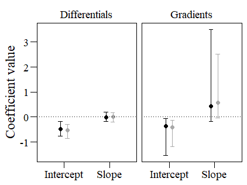

```r
ggplot(selcoefs,
       aes(x=param,y=coef,color=fitness_meas))+
  geom_errorbar(aes(ymin=lower, ymax=upper),
                width=.2,position=position_dodge(.3))+
  geom_point(size=2,position=position_dodge(.3))+
  facet_wrap(~type)+
  geom_hline(yintercept=0,lty=3)+
  scale_color_manual(values=c("black","darkgrey"))+
  scale_y_continuous(breaks=c(-2,-1,0,1,2,3,4))+
  my_theme()+xlab(NULL)+ylab("Coefficient value")
```

```r
# black: mean_fitness_fl, grey: mean_fitness_study
```

## Hypothesis 3

```r
datadef3_BLUPs<-read.csv("data/datadef3_BLUPs.csv")
head(datadef3_BLUPs)
```

|  | year | id_nr | id | fcode | FFD | n_fl | n_fr | totseed | intactseed | shoot_vol | period | n_years_fl_fitness | n_years_study | mean_4 | cmean_4 | intercept | intercept_sd | slope | slope_sd | mean_fitness_study | mean_fitness_fl | cn_shoot_vol_mean_sqrt |
| --- | --- | --- | --- | --- | --- | --- | --- | --- | --- | --- | --- | --- | --- | --- | --- | --- | --- | --- | --- | --- | --- | --- |
| 1 | 1989 | 1 | old_1 | 1 | NA | 6 | 3 | 8 | 6 | 1418.6000 | old | 5 | 8 | 5.236667 | -0.228207783 | -0.7630547 | 1.36656 | -0.2054825 | 0.6866107 | 2.75 | 4.4 | -0.05649976 |
| 2 | 1990 | 1 | old_1 | 0 | NA | 0 | 0 | 0 | 0 | 523.2000 | old | 5 | 8 | 7.195000 | 1.730125551 | -0.7630547 | 1.36656 | -0.2054825 | 0.6866107 | 2.75 | 4.4 | -0.05649976 |
| 3 | 1991 | 1 | old_1 | 1 | 59.91181 | 23 | 3 | 12 | 12 | 1915.4000 | old | 5 | 8 | 5.245000 | -0.219874449 | -0.7630547 | 1.36656 | -0.2054825 | 0.6866107 | 2.75 | 4.4 | -0.05649976 |
| 4 | 1992 | 1 | old_1 | 1 | 55.66944 | 19 | 2 | 6 | 1 | 1460.1917 | old | 5 | 8 | 3.828333 | -1.636541116 | -0.7630547 | 1.36656 | -0.2054825 | 0.6866107 | 2.75 | 4.4 | -0.05649976 |
| 5 | 1993 | 1 | old_1 | 1 | NA | NA | 0 | 0 | 0 | 879.6493 | old | 5 | 8 | 5.461667 | -0.003207783 | -0.7630547 | 1.36656 | -0.2054825 | 0.6866107 | 2.75 | 4.4 | -0.05649976 |
| 6 | 1994 | 1 | old_1 | 1 | 59.18403 | 14 | 1 | 3 | 3 | 1338.6727 | old | 5 | 8 | 6.418333 | 0.953458884 | -0.7630547 | 1.36656 | -0.2054825 | 0.6866107 | 2.75 | 4.4 | -0.05649976 |

## Model in Table 3

Calculate residuals of linear model of slope of the RN on the intercept of the RN, and use these residuals as explanatory variable.

```r
model_residuals3<-lm(slope~intercept,datadef3_BLUPs)
summary(model_residuals3)
```

```
Call:
lm(formula = slope ~ intercept, data = datadef3_BLUPs)

Residuals:
     Min       1Q   Median       3Q      Max
-0.35062 -0.07048  0.00250  0.06973  0.33855

Coefficients:
             Estimate Std. Error t value Pr(>|t|)
(Intercept) -0.001188   0.001692  -0.702    0.483
intercept    0.414769   0.001698 244.255   <2e-16 ***
---
Signif. codes:  0 ‘***’ 0.001 ‘**’ 0.01 ‘*’ 0.05 ‘.’ 0.1 ‘ ’ 1

Residual standard error: 0.111 on 4298 degrees of freedom
Multiple R-squared:  0.9328,    Adjusted R-squared:  0.9328
F-statistic: 5.966e+04 on 1 and 4298 DF,  p-value: < 2.2e-16
```

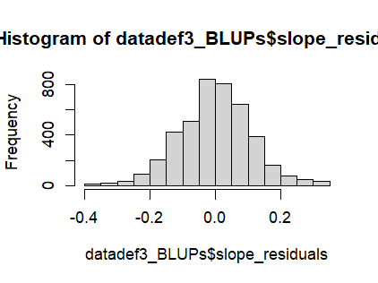

```r
datadef3_BLUPs$slope_residuals<-residuals(model_residuals3)
hist(datadef3_BLUPs$slope_residuals)
```

```r
print(modelBLUP_8_3_brms3,digits=3)
```

```
 Family: zero_inflated_negbinomial
  Links: mu = log; shape = identity; zi = logit
Formula: round(intactseed) ~ slope_residuals * cmean_4 + cn_shoot_vol_mean_sqrt + (1 | id)
         zi ~ slope_residuals * cmean_4 + cn_shoot_vol_mean_sqrt + (1 | id)
   Data: datadef3_BLUPs (Number of observations: 3228)
  Draws: 4 chains, each with iter = 4000; warmup = 1000; thin = 2;
         total post-warmup draws = 6000

Group-Level Effects:
~id (Number of levels: 424)
                 Estimate Est.Error l-95% CI u-95% CI  Rhat Bulk_ESS Tail_ESS
sd(Intercept)       0.246     0.052    0.133    0.340 1.001     2328     2886
sd(zi_Intercept)    0.129     0.085    0.007    0.310 1.004     1994     3419

Population-Level Effects:
                           Estimate Est.Error l-95% CI u-95% CI  Rhat Bulk_ESS Tail_ESS
Intercept                     2.205     0.036    2.133    2.276 1.001     4691     5224
zi_Intercept                  0.724     0.044    0.639    0.810 1.000     4504     4664
slope_residuals               0.338     0.279   -0.214    0.903 1.001     4962     4959
cmean_4                      -0.018     0.029   -0.076    0.040 1.001     4777     5113
cn_shoot_vol_mean_sqrt        0.018     0.003    0.013    0.023 1.000     5145     5266
slope_residuals:cmean_4      -0.062     0.233   -0.520    0.400 1.000     4553     4848
zi_slope_residuals           -1.097     0.360   -1.816   -0.398 1.000     4883     4761
zi_cmean_4                    0.051     0.031   -0.009    0.111 1.000     4842     4725
zi_cn_shoot_vol_mean_sqrt    -0.030     0.003   -0.036   -0.023 1.000     4986     5077
zi_slope_residuals:cmean_4    0.787     0.271    0.263    1.324 1.000     4450     4165

Family Specific Parameters:
      Estimate Est.Error l-95% CI u-95% CI  Rhat Bulk_ESS Tail_ESS
shape    1.385     0.105    1.186    1.595 1.000     4069     4747

Draws were sampled using sampling(NUTS). For each parameter, Bulk_ESS
and Tail_ESS are effective sample size measures, and Rhat is the potential
scale reduction factor on split chains (at convergence, Rhat = 1).
```

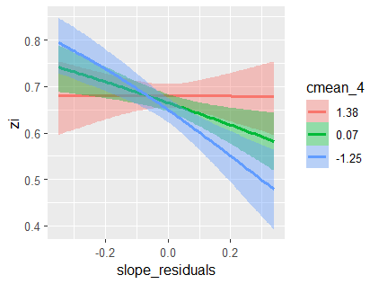

```r
conditional_effects(modelBLUP_8_3_brms3,effects="slope_residuals:cmean_4",
                    dpar="zi")
```